# Initial EDA Basic Outline

Alvin Chen

This is an outline for your Initial EDA. You can follow this outline, or you can modify it as you see fit. Do what works best for your project.

## Research Question

State your specific research question and why it is interesting.

Specific Research Question: What is the correlation between wealth group of countries (high, upper middle, lower middle, low) and their effects on climate change? Which one contributes the most?

Climate change is a problem that impacts our daily lives and it has become a main global issue. Studying the relationships between different countries and their contributions to climate change can be crucial in devising plans to slow climate change on our planet. This topic sparks my interest as it not only effects me, but it also be devastating for the future of out planet.In studying and generating research, helpful insight can be provided to help spread awareness and provide understanding in which group of countries are contributing the most to this global issue.

## Data Processing

#### Data Intake

Include R code and written explanation to import your **TWO** data sets.

```r
#import statements
library(tidyverse)
library(readr)
library(esquisse)
```

```r
co2em_file <- 'https://raw.githubusercontent.com/stat184-summer2023/final-project-alvin-chen/main/API_EN.ATM.CO2E.PC_DS2_en_csv_v2_10576797.csv'

co2em <- read_csv(co2em_file)
head(co2em)
```

| Country Name | Country Code | Indicator Name | Indicator Code | 1960 | 1961 | 1962 | 1963 | 1964 | 1965 | 1966 | 1967 | 1968 | 1969 | 1970 | 1971 | 1972 | 1973 | 1974 | 1975 | 1976 | 1977 | 1978 | 1979 | 1980 | 1981 | 1982 | 1983 | 1984 | 1985 | … |
| --- | --- | --- | --- | --- | --- | --- | --- | --- | --- | --- | --- | --- | --- | --- | --- | --- | --- | --- | --- | --- | --- | --- | --- | --- | --- | --- | --- | --- | --- | --- |
| Aruba | ABW | CO2 emissions (metric tons per capita) | EN.ATM.CO2E.PC | NA | NA | NA | NA | NA | NA | NA | NA | NA | NA | NA | NA | NA | NA | NA | NA | NA | NA | NA | NA | NA | NA | NA | NA | NA | NA | … |
| Afghanistan | AFG | CO2 emissions (metric tons per capita) | EN.ATM.CO2E.PC | 0.0460599 | 0.05360430 | 0.07376479 | 0.07423268 | 0.08629245 | 0.1014674 | 0.1076370 | 0.1237343 | 0.1154977 | 0.08682346 | 0.1502906 | 0.1660420 | 0.1307638 | 0.1362798 | 0.1556494 | 0.1689286 | 0.1547872 | 0.1829636 | 0.1631596 | 0.1683767 | 0.1328586 | 0.1519729 | 0.1648039 | 0.2036356 | 0.2349877 | 0.2978277 | … |
| Angola | AGO | CO2 emissions (metric tons per capita) | EN.ATM.CO2E.PC | 0.0974716 | 0.07903809 | 0.20128908 | 0.19253473 | 0.20100336 | 0.1915284 | 0.2464128 | 0.1549116 | 0.2563160 | 0.41955056 | 0.5286980 | 0.4923022 | 0.6352147 | 0.6706243 | 0.6520234 | 0.5746931 | 0.4158503 | 0.4347550 | 0.6461792 | 0.6369442 | 0.5987173 | 0.5712019 | 0.4852515 | 0.5150715 | 0.4873957 | 0.4431214 | … |
| Albania | ALB | CO2 emissions (metric tons per capita) | EN.ATM.CO2E.PC | 1.2581949 | 1.37418605 | 1.43995596 | 1.18168114 | 1.11174196 | 1.1660990 | 1.3330555 | 1.3637463 | 1.5195513 | 1.55896757 | 1.7532399 | 1.9894979 | 2.5159144 | 2.3038974 | 1.8490067 | 1.9106336 | 2.0135846 | 2.2758764 | 2.5306250 | 2.8982085 | 1.9350583 | 2.6930239 | 2.6248568 | 2.6832399 | 2.6942914 | 2.6580154 | … |
| Andorra | AND | CO2 emissions (metric tons per capita) | EN.ATM.CO2E.PC | NA | NA | NA | NA | NA | NA | NA | NA | NA | NA | NA | NA | NA | NA | NA | NA | NA | NA | NA | NA | NA | NA | NA | NA | NA | NA | … |
| Arab World | ARB | CO2 emissions (metric tons per capita) | EN.ATM.CO2E.PC | 0.6436890 | 0.68515088 | 0.76085451 | 0.87494119 | 0.99909766 | 1.1657054 | 1.2726507 | 1.3314044 | 1.5449425 | 1.78991339 | 1.8012455 | 1.9934862 | 2.1098716 | 2.3967997 | 2.2734407 | 2.1842635 | 2.5687100 | 2.6316284 | 2.7432413 | 2.8426551 | 3.0692088 | 2.9070579 | 2.7011166 | 2.7933569 | 2.9563182 | 3.0355580 | … |

#### Written explanation:

This data was collected by Climate Watch in 2020. The purpose of this data is to display the amount of CO2 emissions by country spread across many years. This data was taken in order to form a correlation between countries and CO2 output.

#### Examine Data Source:

Looking at thee co2em data set, it is clear to see that there are some missing variables for some countries on some years in the table. As a result this data some countries will be removed and ignored in data consideration. In order to contribute to the guiding questions some key variables that stand out are the countries name, and the the years with the emission amount data. To answer my question, I will need to clean my data, and remove some out lier variables that wont contribute to the study.

```r
income_file <- 'https://raw.githubusercontent.com/stat184-summer2023/final-project-alvin-chen/main/Metadata_Country_API_EN.ATM.CO2E.PC_DS2_en_csv_v2_5551837.csv'

income <- read_csv(income_file)
head(income)
```

| Country Code | Region | IncomeGroup | SpecialNotes | TableName | ...6 |
| --- | --- | --- | --- | --- | --- |
| ABW | Latin America & Caribbean | High income | NA | Aruba | NA |
| AFE | NA | NA | 26 countries, stretching from the Red Sea in the North to the Cape of Good Hope in the South (https://www.worldbank.org/en/region/afr/eastern-and-southern-africa) | Africa Eastern and Southern | NA |
| AFG | South Asia | Low income | The reporting period for national accounts data is designated as either calendar year basis (CY) or fiscal year basis (FY). For this country, it is fiscal year-based (fiscal year-end: March 20). Also,… | Afghanistan | NA |
| AFW | NA | NA | 22 countries, stretching from the westernmost point of Africa, across the equator, and partly along the Atlantic Ocean till the Republic of Congo in the South (https://www.worldbank.org/en/region/afr/… | Africa Western and Central | NA |
| AGO | Sub-Saharan Africa | Lower middle income | The World Bank systematically assesses the appropriateness of official exchange rates as conversion factors. In this country, multiple or dual exchange rate activity exists and must be accounted for a… | Angola | NA |
| ALB | Europe & Central Asia | Upper middle income | NA | Albania | NA |

```r
NA
```

#### Written explanation

This data was sourced by The World Bank in 2022. The purpose of this data is to assign whether a country is high to low income class based on their respective values. This data was taken in order to form a correlation between countries and income status.

#### Examine Data Source:

Looking at the income data set, it is clear to see that there are also some missing variables and empty columns. This will lead to the need for data cleaning to remove countries with missing data and removing variables that arent needed for the study such as special notes and region. Variable that will likely be helpful are country names and also the class or income group. To work towards my research question it is planned to clean and merge the data sets as well as the possible creation of new variables to display groups of countries in a decending bar graph.

### Data Wrangling

Include R code and written explanation for wangling your data (you can make multiple wrangled data sets).

```r
# clean the co2em data set
# remove columns with no data
co2em_clean <-
  co2em[, 1:(ncol(co2em) - 5)]

# remove incomplete cases
co2_cleaned <- co2em_clean[complete.cases(co2em_clean), ]

# remove unwanted columns
co2_cleaned <- co2_cleaned[, -c(2:4)]
```

```r
# clean the income data set
# remove unwanted columns and columns with no data
income_clean <-
  income[, c(3, 5)]

# remove incomplete cases
income_cleaned <- income_clean[complete.cases(income_clean), ]

# rename column
names(income_cleaned)[2] <- "Country Name"
```

```r
# merge two datasets into one by country name
co2_income <- merge(income_cleaned, co2_cleaned, by = "Country Name")

# remove space in country name variable
names(co2_income)[1] <- "CountryName"

# covert to long format to graph dates
co2_income_long <- tidyr::gather(co2_income, year, value, -CountryName, -IncomeGroup)

# change names of year and value
names(co2_income_long)[3] <- "Year"
names(co2_income_long)[4] <- "CO2(metric tons per capita)"
```

## Data Visualization

#### Plot 1

Include R code to make one data visualization (I would encourage you to use 3 or more variables). Include a brief written description of what your graph shows. Is this graph helpful in answering your research question? If it is helpful, will you need to add/modify anything in this graph in the final report?

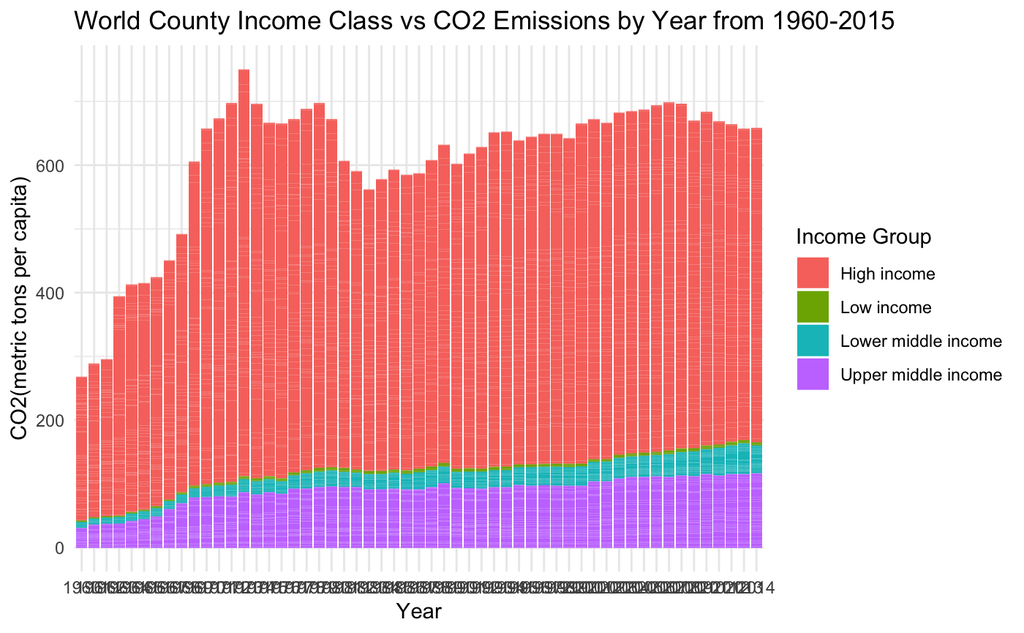

```r
# graph data
ggplot(co2_income_long) +
  geom_col(aes(x = Year,y = `CO2(metric tons per capita)`,fill = IncomeGroup)) +
  scale_fill_hue(direction = 1) +
  labs(
    title = "World County Income Class vs CO2 Emissions by Year from 1960-2015 ",
    fill = "Income Group"
  ) +
  theme_minimal()
```

Explanation: My graph establishes a relationship between the year and the CO2 production and it is colored based on the income group of the providing countries. This graph is helpful in answering my question in terms of which income group contributes the most CO2 emissions in terms of climate change but it lacks help in terms of telling me which countries beling to which group and it also doesn’t answer the second part of my question of which specific country contributed the most throughout the years. For my final report, I might need to sum up all the CO2 emissions from each country and create a new variable to help me answer my question.

#### Plot 2

Include R code to make one data visualization (I would encourage you to use 3 or more variables). Include a brief written description of what your graph shows. Is this graph helpful in answering your research question? If it is helpful, will you need to add/modify anything in this graph in the final report?

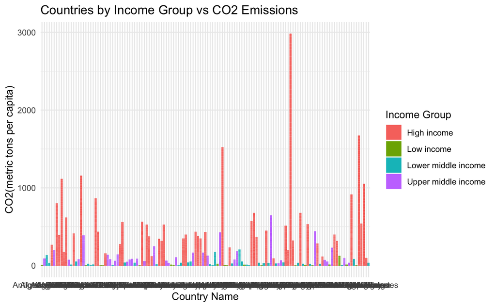

```r
ggplot(co2_income_long) +
  geom_col(aes(x = CountryName,y = `CO2(metric tons per capita)`,fill = IncomeGroup)) +
  scale_fill_hue(direction = 1) +
  labs(
    x = "Country Name",
    title = "Countries by Income Group vs CO2 Emissions",
    fill = "Income Group"
  ) +
  theme_minimal()
```

Explanation: This graph provides insight on Countries by name and which income group they are in and their level of CO2 emission. This graph will prove helpful in answering my questions of which country is the greatest contributory. It offers information on which class also contributed the most but the bars and data are messy and hard to read. Some reorganization and modifications of both graphs are required to enhance readability and provide a more clearer answers to my research questions.

## Conclusion

Include your initial intuition as to what the answer to your research question is using the data sets and visualizations you created.

All in all from composing this EDA, I think I will need to answer my question with the process of multiple graph or maybe subplots to better organize my data. Some common trends I noticed were that higher value countries seem to contribute the most to climate change as they produce the most CO2 emissions and that lower income countries contribute a lot less even compared to middle class and especially high income countries. In order to provide the clearest evidence I need to reorganize my data to enhance readability and probably generate more graphs to make each part of my question clearer. In looking at my research question now I think it is a solid foundation to go off of with concrete evidence that can support a clear answer. With that being said specific parts of the question, could receive specifics to dive deeper into the given issue as climate change can be explored in multiple different ways. In completing this draft, I have paved a clear path to what my final outcome will start to look like.